# sklearn.datasets.load_diabetes

**sklearn.datasets.load_diabetes(*, *return_X_y=False*, *as_frame=False*, *scaled=True*)[[source]](https://github.com/scikit-learn/scikit-learn/blob/f3f51f9b6/sklearn/datasets/_base.py#L954)**

Load and return the diabetes dataset (regression).

| Samples total | 442 |
| --- | --- |
| Dimensionality | 10 |
| Features | real, -.2 < x < .2 |
| Targets | integer 25 - 346 |

Note

The meaning of each feature (i.e. `feature_names`) might be unclear (especially for `ltg`) as the documentation of the original dataset is not explicit. We provide information that seems correct in regard with the scientific literature in this field of research.

Read more in the [User Guide](https://scikit-learn.org/1.1/datasets/toy_dataset.html#diabetes-dataset).

**Parameters:**

**return_X_y**bool, default=False**

If True, returns `(data, target)` instead of a Bunch object. See below for more information about the `data` and `target` object.

New in version 0.18.

**as_frame**bool, default=False**

If True, the data is a pandas DataFrame including columns with appropriate dtypes (numeric). The target is a pandas DataFrame or Series depending on the number of target columns. If `return_X_y` is True, then (`data`, `target`) will be pandas DataFrames or Series as described below.

New in version 0.23.

**scaled**bool, default=True**

If True, the feature variables are mean centered and scaled by the standard deviation times the square root of `n_samples`. If False, raw data is returned for the feature variables.

New in version 1.1.

**Returns:**

**data**`Bunch`**

Dictionary-like object, with the following attributes.

**data{ndarray, dataframe} of shape (442, 10)**

The data matrix. If `as_frame=True`, `data` will be a pandas DataFrame.

**target: {ndarray, Series} of shape (442,)**

The regression target. If `as_frame=True`, `target` will be a pandas Series.

**feature_names: list**

The names of the dataset columns.

**frame: DataFrame of shape (442, 11)**

Only present when `as_frame=True`. DataFrame with `data` and `target`.

New in version 0.23.

**DESCR: str**

The full description of the dataset.

**data_filename: str**

The path to the location of the data.

**target_filename: str**

The path to the location of the target.

**(data, target)**tuple if `return_X_y` is True**

Returns a tuple of two ndarray of shape (n_samples, n_features) A 2D array with each row representing one sample and each column representing the features and/or target of a given sample.

New in version 0.18.

## Examples using `sklearn.datasets.load_diabetes`

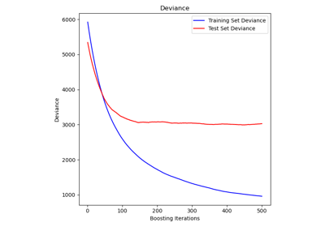

Gradient Boosting regression

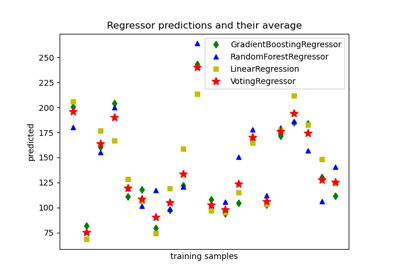

Plot individual and voting regression predictions

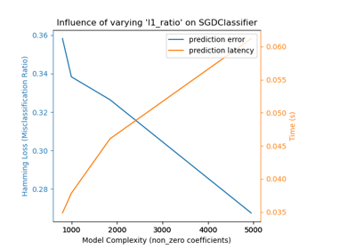

Model Complexity Influence

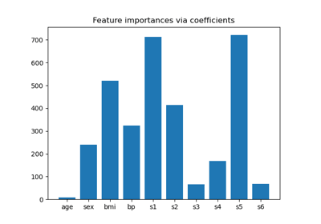

Model-based and sequential feature selection

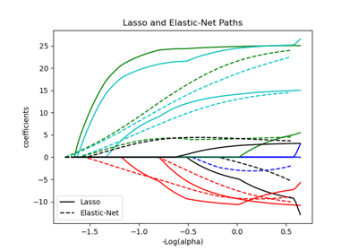

Lasso and Elastic Net

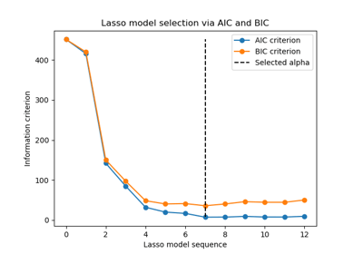

Lasso model selection via information criteria

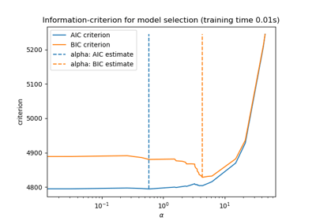

Lasso model selection: AIC-BIC / cross-validation

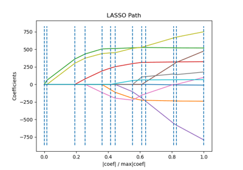

Lasso path using LARS

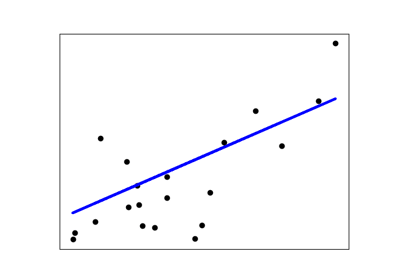

Linear Regression Example

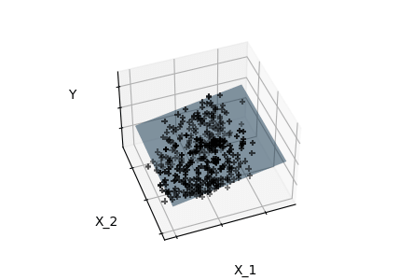

Sparsity Example: Fitting only features 1 and 2

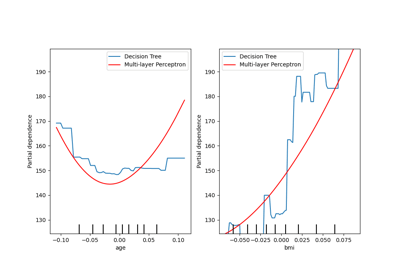

Advanced Plotting With Partial Dependence

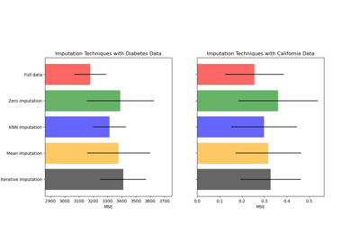

Imputing missing values before building an estimator

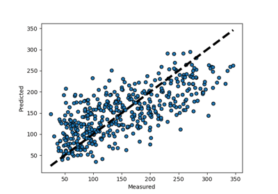

Plotting Cross-Validated Predictions

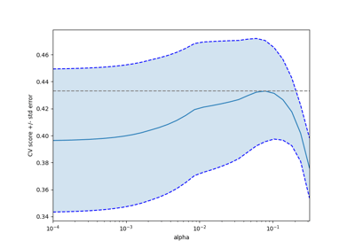

Cross-validation on diabetes Dataset Exercise

© 2007–2022 The scikit-learn developers  
Licensed under the 3-clause BSD License.  
https://scikit-learn.org/1.1/modules/generated/sklearn.datasets.load_diabetes.html